# DEVP229: D-Lab Part 2

Evan

1/13/2021

# Variable assignment, data types and conversions, and data structures

Let’s get acquainted with the basics of programming in RStudio!

### Variable assignment

```r
x <- 5
```

… but, nothing is shown on the screen. Now, “call” (retreive from memory) whatever is inside of `x`:

```r
# The value five prints to the console
x
```

```
## [1] 5
```

R is a one-indexed language and [1] means R starts counting from 1 (not 0, like many other languages). Here we see that there is one thing - in the first and only position - inside of `x`.

### Data Types

These are the five most common classes of data you will encounter:

1. numeric: decimals (the default for ALL numbers in R)
2. integer: whole numbers (positive and negative, including zero)
3. character: text strings (always wrapped in quotations)
4. logical: TRUE or FALSE (1 or 0)
5. factor: nominal or ordinal categorical type

Use the `class()` function to check a variable’s class (type).

Key vocabulary:

- Function: performs actions on things, and usually are followed by trailing round parentheses
- Arguments: the “things” - these go inside of a function’s round parentheses and can be values, text, mathematical expressions, or entire datasets
1. Numeric

```r
class(x)
```

```
## [1] "numeric"
```

2. Integer

We can also convert types! To convert to integer:

```r
x_int <- as.integer(x)
x_int
```

```
## [1] 5
```

```r
class(x_int)
```

```
## [1] "integer"
```

```r
# View the help pages
?as.integer
```

3. Character

```r
# Underscore used as placeholder for space:
my_name <- "Oski"
my_name
```

```
## [1] "Oski"
```

```r
class(my_name)
```

```
## [1] "character"
```

```r
?as.character
```

4. Logical

Logical data are useful for subsetting:

```r
class(TRUE)
```

```
## [1] "logical"
```

```r
# Check out some relational comparisons!
8 > 7
```

```
## [1] TRUE
```

```r
"Berkeley" == "berkeley"
```

```
## [1] FALSE
```

5. Factor

Factor data are what R calls categorical type. see `?factor` to learn more.

Delete variables with `rm`

```r
# Delete x?
rm(x)
x
```

### Data Structures

Unless you are explicitly doing mathematics focused programming, the two most common data structures you will encounter are vectors and dataframes.

- Vector = an ordered group of the same type of data
- Data frame = an ordered group of equal length vectors

Use the `c` function to concatenate a vector, and combine more than one piece of data into one variable:

```r
names <- c("Max", "Sidney", "Tito", "Bella", "Luna", "Ducky")
names
```

```
## [1] "Max"    "Sidney" "Tito"   "Bella"  "Luna"   "Ducky"
```

```r
?c

# This is a "character vector"
# Add notes with a hashtag
class(names)
```

```
## [1] "character"
```

```r
# Or
age <- c(3, 4, 7, 12, 1, 2)
age
```

```
## [1]  3  4  7 12  1  2
```

```r
class(age)
```

```
## [1] "numeric"
```

Combine into data frame

```r
dogs <- data.frame(names, age)
dogs
```

```
##    names age
## 1    Max   3
## 2 Sidney   4
## 3   Tito   7
## 4  Bella  12
## 5   Luna   1
## 6  Ducky   2
```

# Import data

### `read.csv()`

The `read.csv()` function is the simplest way to hard-code the data importation process. A “csv” (comma-separated values) file is a plain text file with commas to designate where column breaks should occur. Other seperators include tab, semicolon, pipe, and fixed-width. Import the lunch dataset now:

```r
lunch <- read.csv("School Lunch Data.csv")
lunch
```

```
##                          School API FLE PE
## 1   Joe A. Gonsalves Elementary 960  16 81
## 2          Old River Elementary 849   0 24
## 3       Sierra Vista Elementary 722  96  6
## 4        West Portal Elementary 914  44 63
## 5   Isabelle Jackson Elementary 754  83 20
## 6          Rio Vista Elementary 796  90 20
## 7      Poplar Avenue Elementary 802  80 18
## 8           Cloverly Elementary 903  46 53
## 9         Creative Arts Charter 844  33 60
## 10  Carolyn A. Clark Elementary 963   6 84
## 11           Raymond Elementary 824  69 25
## 12       Fernangeles Elementary 730 100  7
## 13     Rainbow Ridge Elementary 826  90 14
## 14   Cyrus J. Morris Elementary 882  29 61
## 15 Benjamin Franklin Elementary 882  36 40
## 16          Salvador Elementary 736  65 20
## 17            Bowers Elementary 788  59 31
## 18   Vintage Parkway Elementary 830  54 26
## 19     Balboa Magnet Elementary 981  22 83
## 20        Selby Lane Elementary 730  80  6
```

```r
# Where is RStudio looking?
getwd()
```

```
## [1] "/Users/macbook/Desktop/DEVP229-Spring2021"
```

```r
# Set working directory?
# Click Session --> Set Working Directory --> Choose Directory

# View the "compact structure" (key information):
str(lunch)
```

```
## 'data.frame':    20 obs. of  4 variables:
##  $ School: chr  "Joe A. Gonsalves Elementary" "Old River Elementary" "Sierra Vista Elementary" "West Portal Elementary" ...
##  $ API   : int  960 849 722 914 754 796 802 903 844 963 ...
##  $ FLE   : int  16 0 96 44 83 90 80 46 33 6 ...
##  $ PE    : int  81 24 6 63 20 20 18 53 60 84 ...
```

```r
# View the first six rows
head(lunch)
```

```
##                        School API FLE PE
## 1 Joe A. Gonsalves Elementary 960  16 81
## 2        Old River Elementary 849   0 24
## 3     Sierra Vista Elementary 722  96  6
## 4      West Portal Elementary 914  44 63
## 5 Isabelle Jackson Elementary 754  83 20
## 6        Rio Vista Elementary 796  90 20
```

```r
# Extract just API
lunch$API
```

```
##  [1] 960 849 722 914 754 796 802 903 844 963 824 730 826 882 882 736 788 830 981
## [20] 730
```

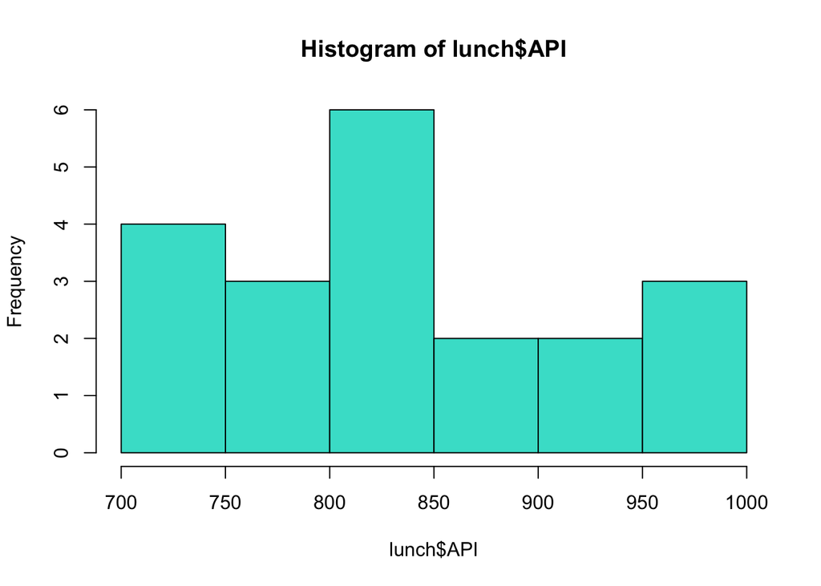

```r
hist(lunch$API, col = "turquoise")
```

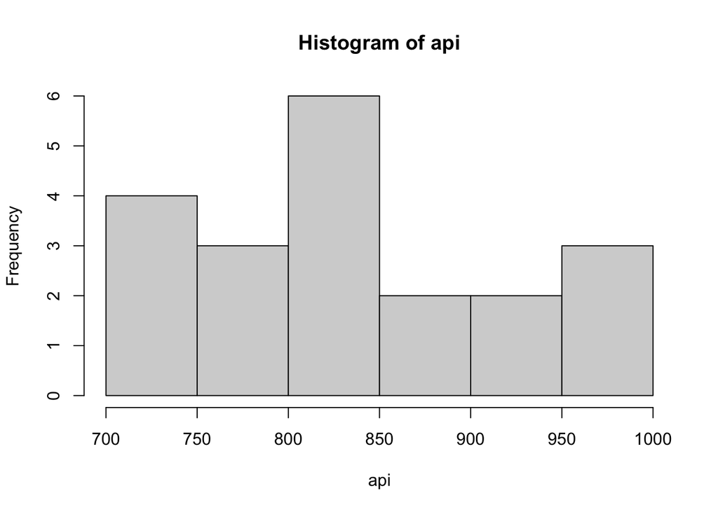

```r
# colors()

api <- lunch$API
hist(api)
```

### The “Import Dataset” button

If this is too confusing, click the “Import Dataset” button at the top right of the “Environment” windowpane in the top right of your RStudio. Then click “From Text (base)…” and then select the lunch dataset. Name it “lunch” and click “OK”.

# One dimensional subsetting

You can extract a single column from a data frame with the `$` operator:

```r
# Show just the "School" variable
lunch$School
```

```
##  [1] "Joe A. Gonsalves Elementary"  "Old River Elementary"
##  [3] "Sierra Vista Elementary"      "West Portal Elementary"
##  [5] "Isabelle Jackson Elementary"  "Rio Vista Elementary"
##  [7] "Poplar Avenue Elementary"     "Cloverly Elementary"
##  [9] "Creative Arts Charter"        "Carolyn A. Clark Elementary"
## [11] "Raymond Elementary"           "Fernangeles Elementary"
## [13] "Rainbow Ridge Elementary"     "Cyrus J. Morris Elementary"
## [15] "Benjamin Franklin Elementary" "Salvador Elementary"
## [17] "Bowers Elementary"            "Vintage Parkway Elementary"
## [19] "Balboa Magnet Elementary"     "Selby Lane Elementary"
```

```r
# Divide the API column by 100 and save in a new column
lunch$new_column <- lunch$API / 100
head(lunch)
```

```
##                        School API FLE PE new_column
## 1 Joe A. Gonsalves Elementary 960  16 81       9.60
## 2        Old River Elementary 849   0 24       8.49
## 3     Sierra Vista Elementary 722  96  6       7.22
## 4      West Portal Elementary 914  44 63       9.14
## 5 Isabelle Jackson Elementary 754  83 20       7.54
## 6        Rio Vista Elementary 796  90 20       7.96
```

```r
lunch
```

```
##                          School API FLE PE new_column
## 1   Joe A. Gonsalves Elementary 960  16 81       9.60
## 2          Old River Elementary 849   0 24       8.49
## 3       Sierra Vista Elementary 722  96  6       7.22
## 4        West Portal Elementary 914  44 63       9.14
## 5   Isabelle Jackson Elementary 754  83 20       7.54
## 6          Rio Vista Elementary 796  90 20       7.96
## 7      Poplar Avenue Elementary 802  80 18       8.02
## 8           Cloverly Elementary 903  46 53       9.03
## 9         Creative Arts Charter 844  33 60       8.44
## 10  Carolyn A. Clark Elementary 963   6 84       9.63
## 11           Raymond Elementary 824  69 25       8.24
## 12       Fernangeles Elementary 730 100  7       7.30
## 13     Rainbow Ridge Elementary 826  90 14       8.26
## 14   Cyrus J. Morris Elementary 882  29 61       8.82
## 15 Benjamin Franklin Elementary 882  36 40       8.82
## 16          Salvador Elementary 736  65 20       7.36
## 17            Bowers Elementary 788  59 31       7.88
## 18   Vintage Parkway Elementary 830  54 26       8.30
## 19     Balboa Magnet Elementary 981  22 83       9.81
## 20        Selby Lane Elementary 730  80  6       7.30
```

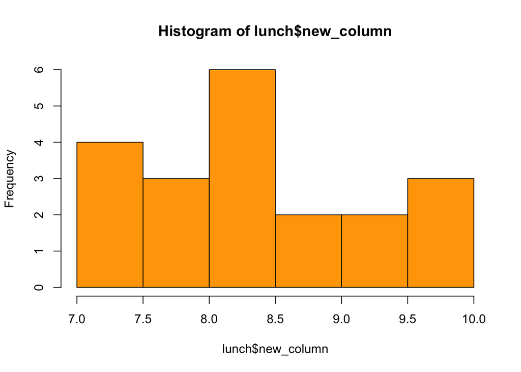

```r
hist(lunch$new_column,
     col = "orange")
```

# Two dimension subsetting

Extract just rows 5 thru 8 and columns 1 and 2

Use bracket notation: df[rows, cols]

```r
lunch_small <- lunch[5:8, 1:2]
lunch_small
```

```
##                        School API
## 5 Isabelle Jackson Elementary 754
## 6        Rio Vista Elementary 796
## 7    Poplar Avenue Elementary 802
## 8         Cloverly Elementary 903
```

What if I want rows 5 thru 8 and 17 - along with columns 1, 2, and 4?

```r
lunch_2 <- lunch[c(5:8, 17) , c(1:2, 4)]
lunch_2
```

```
##                         School API PE
## 5  Isabelle Jackson Elementary 754 20
## 6         Rio Vista Elementary 796 20
## 7     Poplar Avenue Elementary 802 18
## 8          Cloverly Elementary 903 53
## 17           Bowers Elementary 788 31
```

```r
names(lunch)
```

```
## [1] "School"     "API"        "FLE"        "PE"         "new_column"
```

# Logical subsetting

Extract rows of schools only where FLE is less than 30

```r
lunch_FLE30 <- lunch[lunch$FLE < 30, ]
lunch_FLE30
```

```
##                         School API FLE PE new_column
## 1  Joe A. Gonsalves Elementary 960  16 81       9.60
## 2         Old River Elementary 849   0 24       8.49
## 10 Carolyn A. Clark Elementary 963   6 84       9.63
## 14  Cyrus J. Morris Elementary 882  29 61       8.82
## 19    Balboa Magnet Elementary 981  22 83       9.81
```

```r
# Or
?subset
lunch_FLE30 <- subset(lunch, subset = FLE < 30)
lunch_FLE30
```

```
##                         School API FLE PE new_column
## 1  Joe A. Gonsalves Elementary 960  16 81       9.60
## 2         Old River Elementary 849   0 24       8.49
## 10 Carolyn A. Clark Elementary 963   6 84       9.63
## 14  Cyrus J. Morris Elementary 882  29 61       8.82
## 19    Balboa Magnet Elementary 981  22 83       9.81
```

# Summarize

`summary` is a useful R function and will give you the correct output depending on the class of the variable that you pass into it. Pass in a data frame or vector to see length of character data, frequencies of factor/categorical data, and six-number summaries of continuous data;

```r
summary(lunch)
```

```
##     School               API             FLE               PE
##  Length:20          Min.   :722.0   Min.   :  0.00   Min.   : 6.00
##  Class :character   1st Qu.:779.5   1st Qu.: 32.00   1st Qu.:19.50
##  Mode  :character   Median :828.0   Median : 56.50   Median :25.50
##                     Mean   :835.8   Mean   : 54.90   Mean   :37.10
##                     3rd Qu.:887.2   3rd Qu.: 80.75   3rd Qu.:60.25
##                     Max.   :981.0   Max.   :100.00   Max.   :84.00
##    new_column
##  Min.   :7.220
##  1st Qu.:7.795
##  Median :8.280
##  Mean   :8.358
##  3rd Qu.:8.873
##  Max.   :9.810
```

```r
summary(lunch$PE)
```

```
##    Min. 1st Qu.  Median    Mean 3rd Qu.    Max.
##    6.00   19.50   25.50   37.10   60.25   84.00
```

# 3. Visualize

Include basic plots

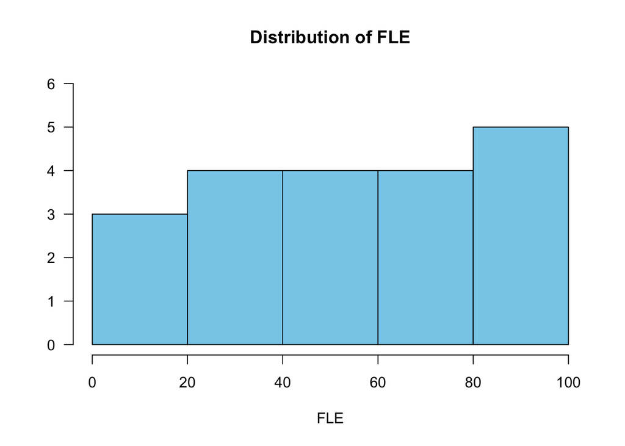

```r
# You can even add a hashtag after a line of runnable code!

hist(lunch$FLE, # column to plot
     breaks = 5, # adjust number of breaks
     col = "skyblue", # change bar color
     main = "Distribution of FLE", # change title
     xlab = "FLE", # change x-axis label
     ylab = "", # Leave blank to omit
     ylim = c(0, 6), # change y-axis limits
     las = 1) # change tickmark orientation
```

```r
?hist
```

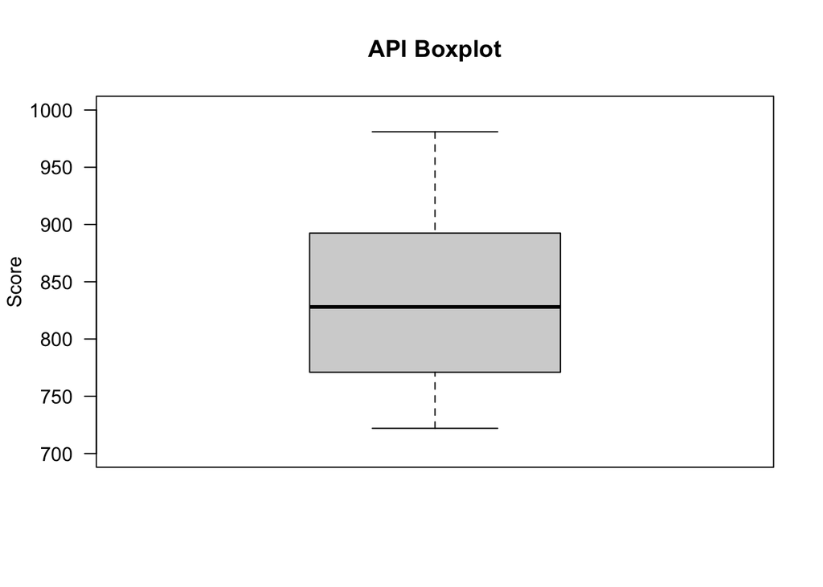

```r
boxplot(lunch$API,
        las = 1,
        ylim = c(700, 1000),
        main = "API Boxplot",
        ylab = "Score")
```

Make gg-plots

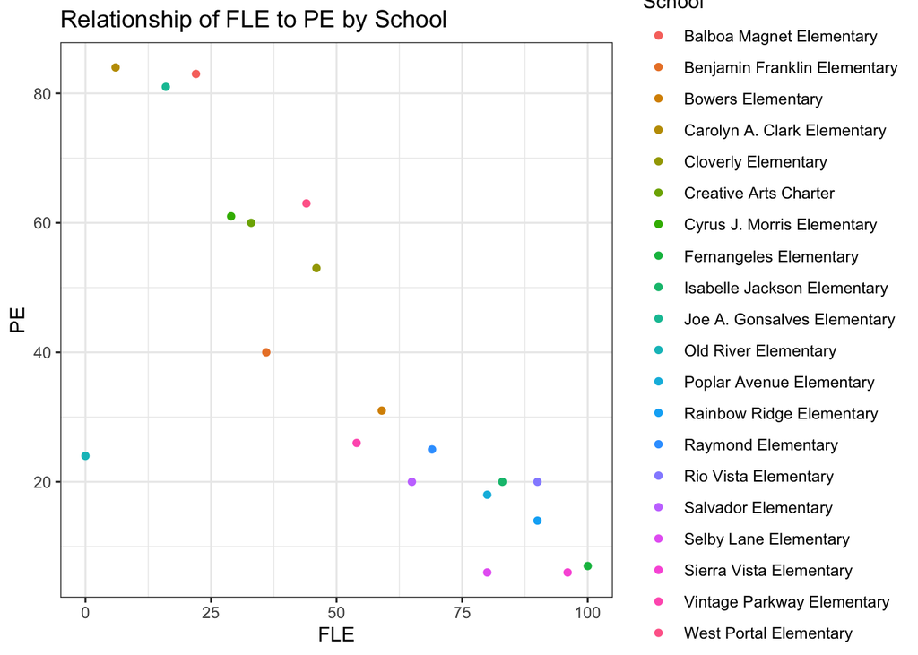

```r
# Unhashtag the line below to install the ggplot2 package
# install.packages("ggplot2")
library(ggplot2)
?ggplot2
?ggplot
ggplot(lunch, aes(x = FLE, y = PE, color = School)) +
  geom_point() +
  theme_bw() +
  ggtitle("Relationship of FLE to PE by School")
```

# 4. Analyze

Ask Dr. Taylor! :)